# **Principles of Data Science Tasks to Perform**

## Categorical-Categorical

Plotting some categorical values

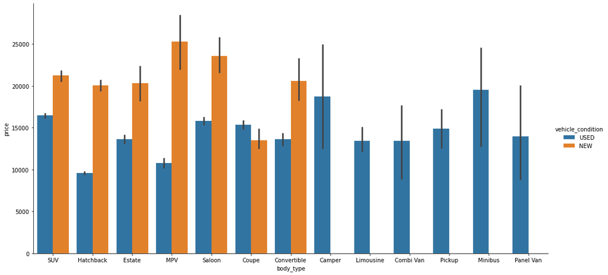

```python
#using a categorical plo to see the distribution of body type aganst price, using vehicle condition to differentiate
plt.figure(figsize=(25, 6))
sns.catplot(data=final_data, x="body_type", y="price", hue="vehicle_condition", kind="bar", height=7, aspect=2);
```

From the plot, there are no new vehicles for Camper, Limousine, Combi Van, Pickup, Minibus and Panel Van. They appear to be all used cars.

Plotting the engineered feature Age against price

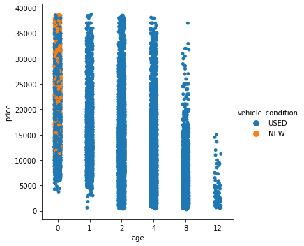

```python
#plotting a categorical plot of Age against Price
sns.catplot(data=final_data, x='age', y='price', hue='vehicle_condition')
```

**We can see from the chart that all new vehicles are aged zero.**

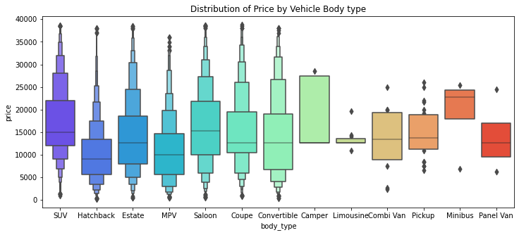

```python
#Using a boxen plot to see the distribution of price by vehicle body type
plt.figure(figsize=(12,5))
sns.boxenplot(x='body_type', y='price', data=final_data, palette='rainbow');
plt.title("Distribution of Price by Vehicle Body type");
```

# Conclusion

From the analysis, I observed that the best predictors of price is:

1. Year of registration
2. Age (Engineered feature from mileage)

Mileage has a negative correlation with the price. The crossover car and van features were not important to the analysis.

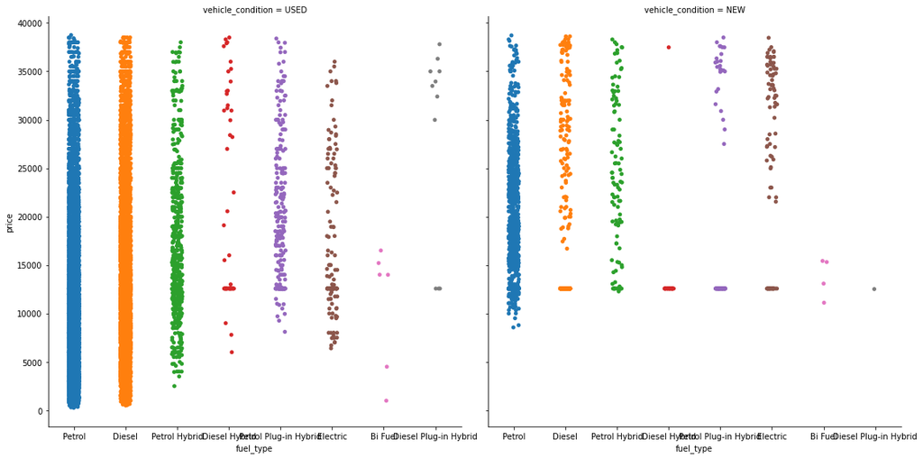

```python
#plotting fuel type against price, using vehicle condition as hue
plt.figure(figsize=(10,10))
sns.catplot(data=final_data, col='vehicle_condition', x='fuel_type', y='price', height=8);
```